# homework 3

Weifeng She

10/12/2016

1. Write down detailed formulas for the gradient of the loss function in the case of logistic regression, and write detailed pseudo code for training a LR model based on gradient descent. Count how many operations are done per each gradient descent iteration and explain how you computed your answer (use the following variables in your answer: n for the number of examples and d for the dimensionality)

#### Calculate the operation for each gradient descent iteration:

##### Step 1, calculate the operations for z:

matrix X_train times $\theta$:

dimension of X_train: n by ( d + 1)

dimension of $\theta$: (d + 1) by 1

for each sample out of n samples, there are (d + 1) multiplications and d additions. Therefore there are n * ( 2d + 1) operations for all n samples.

##### Step 2, calculate operations for H:

Since Y * Z operates on n samples, it counts as n operations.

Exponential (Y * Z) also operates on n samples, counts as n operations.

1 + exponential (Y * Z) operates on n samples, also counts as n operatons.

Y / (1 + exponentila(Y * z)) operates on n samples, counts as n oerations as well.

Therefore there are 4n operations.

##### Step 3, calculate the operation for er_in(in sample error):

Since X_train transpose is not involved in any computation, therefore I did not count it as operation.

Caculate the operations for matrix of transpose of X_train times vector H,

dimension of X_train transpose: (d + 1) by n

dimension of H: n by 1

for each dimension of (d + 1), there are n multiplications and n - 1 additions, therefore there are (2n - 1)(d + 1) total operatoin

then do one division, one multiplication and one subtraction on (d +1) dimension, so 3( d + 1) operation.

therefore there are (2n - 1)(d + 1) + 3(d + 1) operations.

In conclusion, total operations involved in each iteration are : n ( 2d + 1) + 4n + (2n - 1) (d + 1) + 3(d + 1)

= 2dn + n + 4n + 2dn -d + 2n - 1 + 3d + 3

2. Implement in R logistic regression based on gradient descent. To avoid unnecessary slowdown use vectorized code when computing the gradient (avoid loops).

```r
# import all the packages need for this homework
library(ggplot2)
library(reshape)
library(mlbench)
library(glm2)
library(ROCR)
gradient_descent <- function(X, Y, eta = 0.01, max_iteration = 20000, epsilon = 0.0001) {

        theta <- replicate(ncol(X), 0.0)

        for(i in 1:  max_iteration)
        {
                z <- as.matrix(X_train) %*% theta
                H <- Y_train / (1 + exp(-Y_train * z))
                # gradient in-sample error
                er_in <- t(X_train) %*% H / nrow(X_train)
                theta_new <- theta - eta * er_in

                if((any(abs(theta_new - theta))) <= epsilon) {
                               print(i)
                              break;}

                theta <- theta_new

                        }

        theta
  }
```

3. Train and evaluate your code on the BreastCancer data from the mlbench R package.Specifically, randomly divide the dataset into 70% for training and 30% for testing and train on the training set and report your accuracy (fraction of times the model made a mistake) on the train set and on the test set. Repeat the random partition of 70% and 30% 10 times and average the test accuracy results over the 10 repetitions. Try several different selections of starting positions - did this change the parameter value that the model learned? Try to play with different convergence criteria to get better accuracy.

```r
data(BreastCancer)
dim(BreastCancer)
```

```
## [1] 699  11
```

```r
head(BreastCancer)
```

```
##        Id Cl.thickness Cell.size Cell.shape Marg.adhesion Epith.c.size
## 1 1000025            5         1          1             1            2
## 2 1002945            5         4          4             5            7
## 3 1015425            3         1          1             1            2
## 4 1016277            6         8          8             1            3
## 5 1017023            4         1          1             3            2
## 6 1017122            8        10         10             8            7
##   Bare.nuclei Bl.cromatin Normal.nucleoli Mitoses     Class
## 1           1           3               1       1    benign
## 2          10           3               2       1    benign
## 3           2           3               1       1    benign
## 4           4           3               7       1    benign
## 5           1           3               1       1    benign
## 6          10           9               7       1 malignant
```

```r
# check the missing values
sapply(BreastCancer, function(x) sum(is.na(x)))
```

```
##              Id    Cl.thickness       Cell.size      Cell.shape
##               0               0               0               0
##   Marg.adhesion    Epith.c.size     Bare.nuclei     Bl.cromatin
##               0               0              16               0
## Normal.nucleoli         Mitoses           Class
##               0               0               0
```

```r
sapply(BreastCancer, function(x) length(unique(x)))
```

```
##              Id    Cl.thickness       Cell.size      Cell.shape
##             645              10              10              10
##   Marg.adhesion    Epith.c.size     Bare.nuclei     Bl.cromatin
##              10              10              11              10
## Normal.nucleoli         Mitoses           Class
##              10               9               2
```

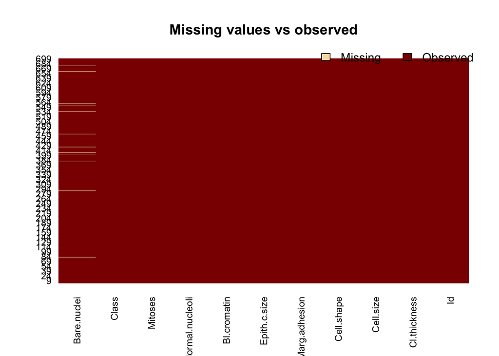

```r
library(Amelia)
missmap(BreastCancer, main = "Missing values vs observed")
```

```r
# check the encoding for each column
sapply(BreastCancer, function(x) is.factor(x))
```

```
##              Id    Cl.thickness       Cell.size      Cell.shape
##           FALSE            TRUE            TRUE            TRUE
##   Marg.adhesion    Epith.c.size     Bare.nuclei     Bl.cromatin
##            TRUE            TRUE            TRUE            TRUE
## Normal.nucleoli         Mitoses           Class
##            TRUE            TRUE            TRUE
```

```r
# we can see all the columns are factor variable, so we need to convert all of them except for last to numeric

# convert the factor to numeric
for(i in 2:10){
  BreastCancer[, i] <- as.numeric(as.character(BreastCancer[, i]))
}

# convert missing value to the meaning
BreastCancer$Bare.nuclei[is.na(BreastCancer$Bare.nuclei)] <-
  mean(BreastCancer$Bare.nuclei, na.rm = T)
# make sure all NA is converted to numeric

sum(is.na(BreastCancer$Bare.nuclei))
```

```
## [1] 0
```

```r
# modeling
# remove labelling column

BreastCancer$Id <- NULL
BreastCancer$Class <- ifelse(BreastCancer$Class == "malignant", 1, 0)
#head(train)
sample_size <- floor(0.7 * nrow(BreastCancer))
train_index <- sample(seq_len(nrow(BreastCancer)), size = sample_size)
train <- BreastCancer[train_index,]
test <- BreastCancer[-train_index,]
```

4. Repeat (3) but this time using logistic regression training code from an R package such as glm2. How did the accuracy in (4) compare to the accuracy in (3).

```r
glm_model <- glm2(Class~., family = binomial(link = "logit"), data = train)

summary(glm_model)
```

```
##
## Call:
## glm2(formula = Class ~ ., family = binomial(link = "logit"),
##     data = train)
##
## Deviance Residuals:
##      Min        1Q    Median        3Q       Max
## -2.95530  -0.14414  -0.08695   0.03899   2.27849
##
## Coefficients:
##                  Estimate Std. Error z value Pr(>|z|)
## (Intercept)     -8.824167   1.084276  -8.138 4.01e-16 ***
## Cl.thickness     0.440595   0.148486   2.967   0.0030 **
## Cell.size        0.178200   0.239937   0.743   0.4577
## Cell.shape       0.287727   0.259740   1.108   0.2680
## Marg.adhesion    0.228256   0.123953   1.841   0.0656 .
## Epith.c.size     0.014984   0.172090   0.087   0.9306
## Bare.nuclei      0.417177   0.101561   4.108 4.00e-05 ***
## Bl.cromatin      0.374054   0.179681   2.082   0.0374 *
## Normal.nucleoli -0.006292   0.119324  -0.053   0.9579
## Mitoses          0.550169   0.432211   1.273   0.2030
## ---
## Signif. codes:  0 '***' 0.001 '**' 0.01 '*' 0.05 '.' 0.1 ' ' 1
##
## (Dispersion parameter for binomial family taken to be 1)
##
##     Null deviance: 629.213  on 488  degrees of freedom
## Residual deviance:  96.254  on 479  degrees of freedom
## AIC: 116.25
##
## Number of Fisher Scoring iterations: 8
```

```r
anova(glm_model, test = "Chisq")
```

```
## Analysis of Deviance Table
##
## Model: binomial, link: logit
##
## Response: Class
##
## Terms added sequentially (first to last)
##
##
##                 Df Deviance Resid. Df Resid. Dev  Pr(>Chi)
## NULL                              488     629.21
## Cl.thickness     1  293.238       487     335.98 < 2.2e-16 ***
## Cell.size        1  173.127       486     162.85 < 2.2e-16 ***
## Cell.shape       1   13.062       485     149.79 0.0003013 ***
## Marg.adhesion    1   11.804       484     137.98 0.0005909 ***
## Epith.c.size     1    1.144       483     136.84 0.2848441
## Bare.nuclei      1   32.900       482     103.94 9.703e-09 ***
## Bl.cromatin      1    4.456       481      99.48 0.0347819 *
## Normal.nucleoli  1    0.000       480      99.48 0.9916868
## Mitoses          1    3.228       479      96.25 0.0723869 .
## ---
## Signif. codes:  0 '***' 0.001 '**' 0.01 '*' 0.05 '.' 0.1 ' ' 1
```

```r
fitted_results <- predict(glm_model, newdata = test, type = "response")
fitted_results <- ifelse(fitted_results > 0.5, 1, 0)
miss_classific_error <- mean(fitted_results != test$Class)
print(paste('Accuracy', 1- miss_classific_error))
```

```
## [1] "Accuracy 0.985714285714286"
```

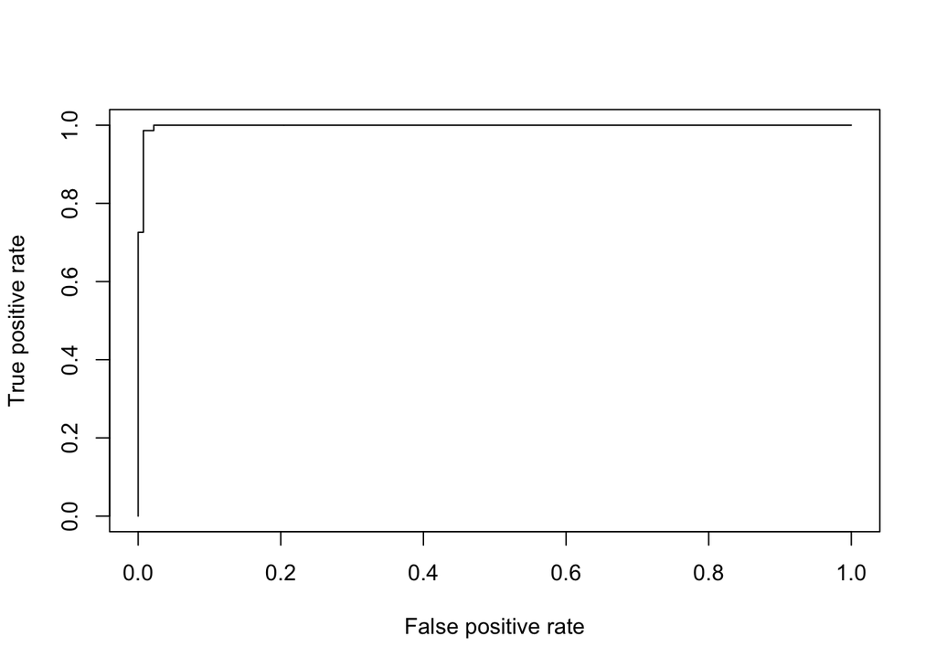

```r
p <- predict(glm_model, newdata = test, type = "response")
pr <- prediction(p, test$Class)
prf <- performance(pr, measure = 'tpr', x.measure = 'fpr')

plot(prf)
```

```r
# ROC is a curve generated by plotting the true positive rate(TPR) against the
# false positive rate(FPR) at various threshold setting while the AUC area
# under the ROC curve.
auc <- performance(pr, measure = "auc")
auc <- auc@y.values[[1]]
auc
```

```
## [1] 0.9978002
```

5. Repeat (4), but replace the 70%-30% train-test split with each of the following splits: 5%-95%, 10%-90%, …, 95%-5%. Graph the accuracy over the training set and over the testing set as a function of the size of the train set. Remember to average the accuracy over 10 random divisions of the data into train and test sets of the above sizes so the graphs will be less noisy.